# Data summary of my five flux towers

Author

Anna Eckert

Published

November 19, 2026

```r
library(here)
library(readr)
library(dplyr)
library(tidyr)
library(ggplot2)
library(knitr)

source(here("R", "read_hh.R"))

my_sites <- c("DE-Lnf", "FI-Let", "US-Kon", "CN-Lch", "AU-Cpr")

snap_file <- list.files(here("data", "snapshots"), pattern = "\\.csv$", full.names = TRUE)
snap <- read_csv(snap_file, show_col_types = FALSE) |>
  filter(site_id %in% my_sites)

# Einlesen der fünf Towers (mit Zwischenspeicher, damit das Rendern schneller ist)
cache <- here("data", "processed", "all_hh.rds")
if (file.exists(cache)) {
  all_hh <- readRDS(cache)
} else {
  zips <- list.files(here("data", "raw"), pattern = "\\.zip$", full.names = TRUE)
  all_hh <- bind_rows(lapply(zips, read_hh, exdir = here("data", "raw", "unzipped")))
  saveRDS(all_hh, cache)
}

# DE-Lnf has no _VUT_ NEE/GPP/RECO in its file: use the _CUT_REF variants instead
all_hh <- all_hh |>
  mutate(used_cut        = site == "DE-Lnf",
         NEE_VUT_REF     = if_else(used_cut, NEE_CUT_REF,     NEE_VUT_REF),
         NEE_VUT_REF_QC  = if_else(used_cut, NEE_CUT_REF_QC,  NEE_VUT_REF_QC),
         GPP_NT_VUT_REF  = if_else(used_cut, GPP_NT_CUT_REF,  GPP_NT_VUT_REF),
         RECO_NT_VUT_REF = if_else(used_cut, RECO_NT_CUT_REF, RECO_NT_VUT_REF))
```

# C1. Site overview

Data source: FLUXNET Shuttle snapshot fluxnet_shuttle_snapshot_20261119T101149.csv. File versions: AMF_US-Kon_FLUXNET_2004-2019_v1.3_r1.zip; ICOS_FI-Let_FLUXNET_2010-2025_v1.3_r1.zip; EUF_DE-Lnf_FLUXNET_2002-2024_v1.3_r1.zip; CNF_CN-Lch_FLUXNET_2008-2020_v1.3_r1.zip; TERN_AU-Cpr_FLUXNET_2010-2025_v1.3_r1.zip. Half-hourly time stamps are in local standard time (no daylight-saving shift).

```r
overview <- snap |>
  transmute(Site = site_id, Name = site_name,
            Country = substr(site_id, 1, 2), IGBP = igbp,
            Lat = round(location_lat, 2), Lon = round(location_long, 2),
            `First year` = first_year, `Last year` = last_year,
            Hub = data_hub, Citation = product_citation)
kable(overview)
```

[output not shown]

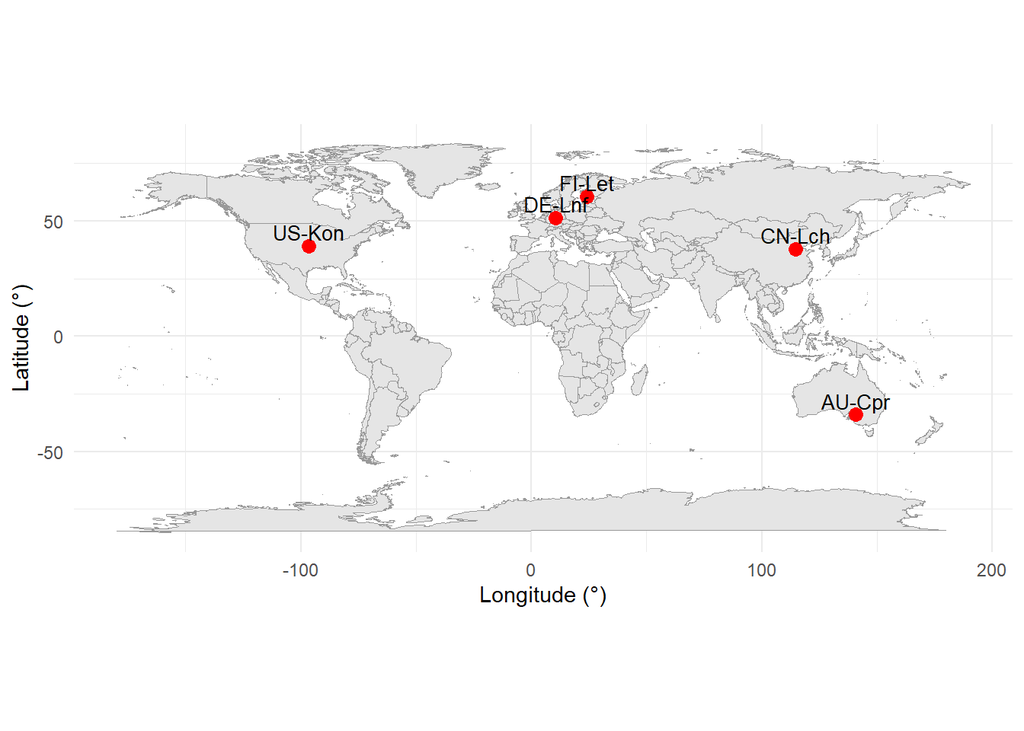

Location of the five flux towers.

```r
world <- map_data("world")
ggplot() +
  geom_polygon(data = world, aes(long, lat, group = group),
               fill = "grey90", colour = "grey60", linewidth = 0.2) +
  geom_point(data = snap, aes(location_long, location_lat), colour = "red", size = 3) +
  geom_text(data = snap, aes(location_long, location_lat, label = site_id),
            nudge_y = 6, size = 3.5) +
  coord_quickmap() +
  labs(x = "Longitude (°)", y = "Latitude (°)") +
  theme_minimal()
```

# C2. Data coverage

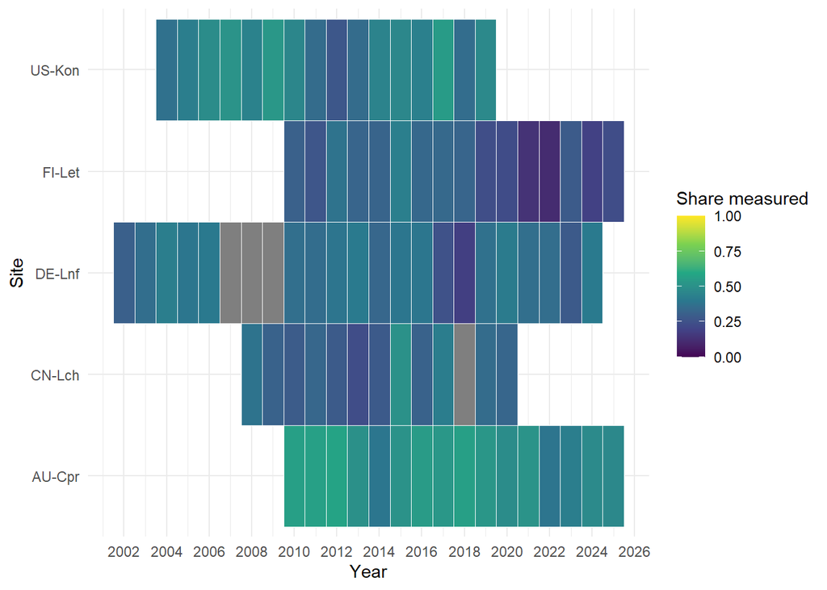

Share of half hours with measured NEE (NEE_VUT_REF_QC == 0) per site and year.

```r
coverage <- all_hh |>
  mutate(year = as.integer(format(time, "%Y"))) |>
  group_by(site, year) |>
  summarise(share = mean(NEE_VUT_REF_QC == 0, na.rm = TRUE), .groups = "drop")

ggplot(coverage, aes(year, site, fill = share)) +
  geom_tile(colour = "white") +
  scale_fill_viridis_c(limits = c(0, 1), name = "Share measured") +
  scale_x_continuous(breaks = seq(2002, 2026, 2)) +
  labs(x = "Year", y = "Site") +
  theme_minimal()
```

```r
best <- coverage |> arrange(desc(share)) |> slice(1)
```

Best coverage: site AU-Cpr in 2012 (58 % of half hours measured).

For DE-Lnf, the delivered file contains no *VUT* values for NEE, GPP and RECO. The _CUT_REF variants (constant USTAR threshold) were used instead (NEE_CUT_REF, GPP_NT_CUT_REF, RECO_NT_CUT_REF). DE-Lnf has no data in 2007–2009 and partial gaps in 2022–2023.

# C3. Summary statistics

Mean, minimum, maximum and share of missing half hours (`NA` after reading −9999) per site, computed from the half-hourly data. For precipitation (`P_F`), the mean is the **mean annual sum** over complete years; minimum and maximum are per half hour.

```r
var_labels <- c(
  TA_F            = "Air temperature TA_F (°C)",
  SW_IN_F         = "Incoming shortwave SW_IN_F (W m⁻²)",
  VPD_F           = "Vapour pressure deficit VPD_F (hPa)",
  P_F             = "Precipitation P_F (mm yr⁻¹ mean; min/max in mm per 30 min)",
  NEE_VUT_REF     = "NEE_VUT_REF (µmol CO₂ m⁻² s⁻¹)",
  GPP_NT_VUT_REF  = "GPP_NT_VUT_REF (µmol CO₂ m⁻² s⁻¹)",
  RECO_NT_VUT_REF = "RECO_NT_VUT_REF (µmol CO₂ m⁻² s⁻¹)",
  H_F_MDS         = "Sensible heat H_F_MDS (W m⁻²)",
  LE_F_MDS        = "Latent heat LE_F_MDS (W m⁻²)"
)

long <- all_hh |>
  select(site, all_of(names(var_labels))) |>
  pivot_longer(-site, names_to = "var", values_to = "value")

stats <- long |>
  group_by(site, var) |>
  summarise(mean = mean(value, na.rm = TRUE),
            min  = min(value, na.rm = TRUE),
            max  = max(value, na.rm = TRUE),
            pct_missing = 100 * mean(is.na(value)),
            .groups = "drop")

# Mean annual precipitation sum (complete years only)
precip <- all_hh |>
  mutate(year = as.integer(format(time, "%Y"))) |>
  group_by(site, year) |>
  summarise(n = n(), annual = sum(P_F, na.rm = TRUE), .groups = "drop") |>
  filter(n >= 17520) |>
  group_by(site) |>
  summarise(p_annual = mean(annual), .groups = "drop")

stats <- stats |>
  left_join(precip, by = "site") |>
  mutate(mean = if_else(var == "P_F", p_annual, mean),
         Variable = factor(var_labels[var], levels = var_labels)) |>
  arrange(site, Variable)

for (s in my_sites) {
  cat("\n\n### ", s, "\n\n")
  tab <- stats |>
    filter(site == s) |>
    transmute(Variable, Mean = mean, Min = min, Max = max, `Missing (%)` = pct_missing)
  cat(kable(tab, digits = 2), sep = "\n")
}
```

### DE-Lnf

| Variable | Mean | Min | Max | Missing (%) |
| --- | --- | --- | --- | --- |
| Air temperature TA_F (°C) | 8.78 | -20.48 | 36.26 | 0.00 |
| Incoming shortwave SW_IN_F (W m⁻²) | 126.44 | 0.00 | 1103.30 | 0.00 |
| Vapour pressure deficit VPD_F (hPa) | 3.49 | 0.00 | 48.40 | 0.00 |
| Precipitation P_F (mm yr⁻¹ mean; min/max in mm per 30 min) | 575.75 | 0.00 | 20.20 | 0.00 |
| NEE_VUT_REF (µmol CO₂ m⁻² s⁻¹) | -1.63 | -64.42 | 26.77 | 16.21 |
| GPP_NT_VUT_REF (µmol CO₂ m⁻² s⁻¹) | 4.18 | -24.78 | 67.12 | 16.21 |
| RECO_NT_VUT_REF (µmol CO₂ m⁻² s⁻¹) | 2.53 | 0.00 | 11.45 | 16.21 |
| Sensible heat H_F_MDS (W m⁻²) | 21.55 | -50.00 | 499.86 | 15.68 |
| Latent heat LE_F_MDS (W m⁻²) | 26.73 | -49.88 | 593.30 | 16.19 |

### FI-Let

| Variable | Mean | Min | Max | Missing (%) |
| --- | --- | --- | --- | --- |
| Air temperature TA_F (°C) | 5.67 | -29.78 | 30.87 | 0.00 |
| Incoming shortwave SW_IN_F (W m⁻²) | 104.76 | 0.00 | 979.80 | 0.00 |
| Vapour pressure deficit VPD_F (hPa) | 2.55 | 0.00 | 31.53 | 0.00 |
| Precipitation P_F (mm yr⁻¹ mean; min/max in mm per 30 min) | 604.17 | 0.00 | 28.64 | 0.00 |
| NEE_VUT_REF (µmol CO₂ m⁻² s⁻¹) | -0.05 | -78.14 | 45.69 | 1.13 |
| GPP_NT_VUT_REF (µmol CO₂ m⁻² s⁻¹) | 3.28 | -43.87 | 78.14 | 1.13 |
| RECO_NT_VUT_REF (µmol CO₂ m⁻² s⁻¹) | 3.24 | 0.00 | 17.02 | 1.13 |
| Sensible heat H_F_MDS (W m⁻²) | 36.17 | -247.60 | 922.20 | 0.74 |
| Latent heat LE_F_MDS (W m⁻²) | 29.98 | -297.00 | 987.00 | 0.74 |

### US-Kon

| Variable | Mean | Min | Max | Missing (%) |
| --- | --- | --- | --- | --- |
| Air temperature TA_F (°C) | 13.26 | -23.27 | 40.62 | 0.00 |
| Incoming shortwave SW_IN_F (W m⁻²) | 181.41 | 0.00 | 1094.10 | 0.00 |
| Vapour pressure deficit VPD_F (hPa) | 7.55 | 0.00 | 62.63 | 0.00 |
| Precipitation P_F (mm yr⁻¹ mean; min/max in mm per 30 min) | 713.56 | 0.00 | 35.56 | 0.00 |
| NEE_VUT_REF (µmol CO₂ m⁻² s⁻¹) | -0.31 | -77.37 | 49.96 | 2.28 |
| GPP_NT_VUT_REF (µmol CO₂ m⁻² s⁻¹) | 4.10 | -44.83 | 82.02 | 2.28 |
| RECO_NT_VUT_REF (µmol CO₂ m⁻² s⁻¹) | 3.81 | 0.00 | 17.96 | 2.28 |
| Sensible heat H_F_MDS (W m⁻²) | 20.12 | -217.83 | 595.24 | 2.28 |
| Latent heat LE_F_MDS (W m⁻²) | 54.95 | -178.56 | 728.61 | 2.28 |

### CN-Lch

| Variable | Mean | Min | Max | Missing (%) |
| --- | --- | --- | --- | --- |
| Air temperature TA_F (°C) | 12.61 | -27.60 | 46.29 | 0.00 |
| Incoming shortwave SW_IN_F (W m⁻²) | 155.14 | 0.00 | 1200.84 | 0.00 |
| Vapour pressure deficit VPD_F (hPa) | 7.24 | 0.00 | 87.94 | 0.00 |
| Precipitation P_F (mm yr⁻¹ mean; min/max in mm per 30 min) | 413.66 | 0.00 | 69.40 | 0.00 |
| NEE_VUT_REF (µmol CO₂ m⁻² s⁻¹) | -1.77 | -79.86 | 49.98 | 9.45 |
| GPP_NT_VUT_REF (µmol CO₂ m⁻² s⁻¹) | 5.59 | -49.49 | 103.01 | 9.45 |
| RECO_NT_VUT_REF (µmol CO₂ m⁻² s⁻¹) | 3.75 | 0.00 | 29.63 | 9.45 |
| Sensible heat H_F_MDS (W m⁻²) | 15.69 | -196.75 | 467.48 | 9.19 |
| Latent heat LE_F_MDS (W m⁻²) | 52.09 | -299.63 | 827.03 | 9.19 |

### AU-Cpr

| Variable | Mean | Min | Max | Missing (%) |
| --- | --- | --- | --- | --- |
| Air temperature TA_F (°C) | 18.02 | 0.00 | 47.72 | 0.00 |
| Incoming shortwave SW_IN_F (W m⁻²) | 217.18 | 0.00 | 1255.00 | 0.00 |
| Vapour pressure deficit VPD_F (hPa) | 12.97 | 0.00 | 101.60 | 0.00 |
| Precipitation P_F (mm yr⁻¹ mean; min/max in mm per 30 min) | 242.37 | 0.00 | 20.20 | 0.00 |
| NEE_VUT_REF (µmol CO₂ m⁻² s⁻¹) | -0.51 | -30.53 | 34.30 | 4.55 |
| GPP_NT_VUT_REF (µmol CO₂ m⁻² s⁻¹) | 1.28 | -33.89 | 31.02 | 4.55 |
| RECO_NT_VUT_REF (µmol CO₂ m⁻² s⁻¹) | 0.76 | 0.00 | 6.21 | 4.55 |
| Sensible heat H_F_MDS (W m⁻²) | 62.60 | -99.00 | 599.00 | 4.18 |
| Latent heat LE_F_MDS (W m⁻²) | 18.16 | -80.00 | 512.00 | 4.18 |

# C4. Time series

Half-hourly data were aggregated to daily means (only days with all 48 half hours). Daily means in µmol CO₂ m⁻² s⁻¹ were multiplied by 1.0378 to get g C m⁻² d⁻¹ (× 86 400 s × 12.011 g mol⁻¹ × 10⁻⁶). Variables: `NEE_VUT_REF`, `GPP_NT_VUT_REF` (night-time partitioning) and `RECO_NT_VUT_REF`.

```r
conv <- 1.0378

daily <- all_hh |>
  mutate(date = as.Date(time)) |>
  group_by(site, date) |>
  summarise(n = n(),
            NEE  = mean(NEE_VUT_REF, na.rm = TRUE) * conv,
            GPP  = mean(GPP_NT_VUT_REF, na.rm = TRUE) * conv,
            RECO = mean(RECO_NT_VUT_REF, na.rm = TRUE) * conv,
            .groups = "drop") |>
  filter(n == 48) |>
  select(-n)

daily_long <- daily |>
  pivot_longer(c(NEE, GPP, RECO), names_to = "flux", values_to = "value")
```

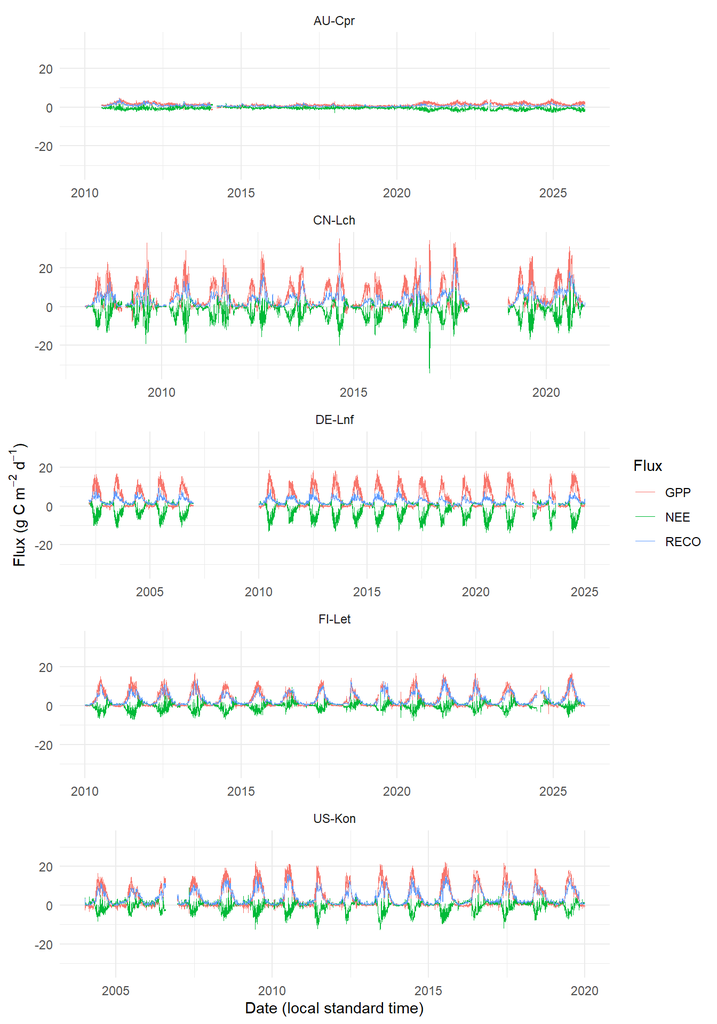

Daily NEE, GPP and RECO (g C m⁻² d⁻¹) over the whole record, one panel per site.

```r
ggplot(daily_long, aes(date, value, colour = flux)) +
  geom_line(linewidth = 0.3) +
  facet_wrap(~site, ncol = 1, scales = "free_x") +
  labs(x = "Date (local standard time)",
       y = expression("Flux (g C " * m^-2 * " " * d^-1 * ")"),
       colour = "Flux") +
  theme_minimal()
```

Check of my aggregation against the daily `FLUXMET_DD` file of site US-Kon:

```r
zip_kon <- list.files(here("data", "raw"), pattern = "US-Kon.*\\.zip$", full.names = TRUE)
dd_name <- grep("FLUXMET_DD", unzip(zip_kon, list = TRUE)$Name, value = TRUE)
unzip(zip_kon, files = dd_name, exdir = here("data", "raw", "unzipped"))

dd <- read_csv(file.path(here("data", "raw", "unzipped"), dd_name),
               na = "-9999", col_select = any_of(c("TIMESTAMP", "NEE_VUT_REF")),
               col_types = cols(TIMESTAMP = "c", .default = "d")) |>
  mutate(date = as.Date(TIMESTAMP, format = "%Y%m%d"))

cmp <- daily |>
  filter(site == "US-Kon") |>
  inner_join(dd, by = "date", suffix = c("_mine", "_dd"))

c(n_days = nrow(cmp),
  correlation = cor(cmp$NEE, cmp$NEE_VUT_REF, use = "complete.obs"),
  max_abs_diff = max(abs(cmp$NEE - cmp$NEE_VUT_REF), na.rm = TRUE))
```

```
      n_days  correlation max_abs_diff
5.844000e+03 1.000000e+00 9.387158e-04
```

# C5. Diurnal cycles

Seasons are defined by meteorological months and **latitude**: for sites with latitude ≥ 0 (northern hemisphere) DJF = winter, MAM = spring, JJA = summer, SON = autumn. For AU-Cpr (latitude < 0, southern hemisphere) the seasons are shifted by six months (DJF = summer, JJA = winter, and so on). Hour of day is local standard time. Fluxes are half-hourly means over the whole record (NEE in µmol CO₂ m⁻² s⁻¹, LE in W m⁻²). For DE-Lnf, NEE is based on `NEE_CUT_REF`.

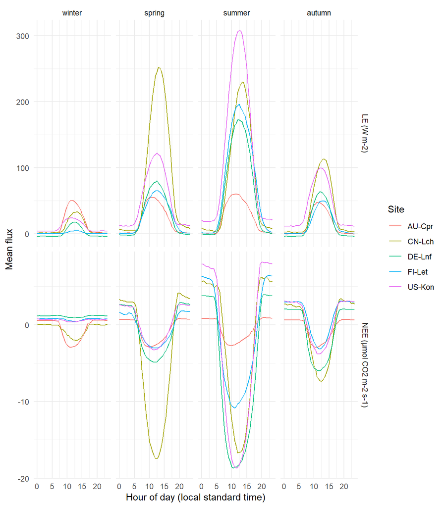

Mean diurnal cycle of NEE and LE per season, all five sites.

```r
lat_tab <- snap |> select(site = site_id, lat = location_lat)

season_of <- function(month, lat) {
  s <- c("winter", "winter", "spring", "spring", "spring", "summer",
         "summer", "summer", "autumn", "autumn", "autumn", "winter")[month]
  south <- c(winter = "summer", spring = "autumn", summer = "winter", autumn = "spring")
  ifelse(lat < 0, south[s], s)
}

diurnal <- all_hh |>
  left_join(lat_tab, by = "site") |>
  mutate(month  = as.integer(format(time, "%m")),
         hour   = as.integer(format(time, "%H")) + as.integer(format(time, "%M")) / 60,
         season = factor(season_of(month, lat),
                         levels = c("winter", "spring", "summer", "autumn"))) |>
  group_by(site, season, hour) |>
  summarise(NEE = mean(NEE_VUT_REF, na.rm = TRUE),
            LE  = mean(LE_F_MDS, na.rm = TRUE), .groups = "drop") |>
  pivot_longer(c(NEE, LE), names_to = "variable", values_to = "value") |>
  mutate(variable = recode(variable,
                           NEE = "NEE (µmol CO2 m-2 s-1)",
                           LE  = "LE (W m-2)"))

ggplot(diurnal, aes(hour, value, colour = site)) +
  geom_line() +
  facet_grid(variable ~ season, scales = "free_y") +
  labs(x = "Hour of day (local standard time)", y = "Mean flux", colour = "Site") +
  theme_minimal()
```

# C6. Your reading

## Energy balance (US-Kon)

Only half hours with measured H and LE (`H_F_MDS_QC == 0`, `LE_F_MDS_QC == 0`) and available `NETRAD` and `G_F_MDS` are used.

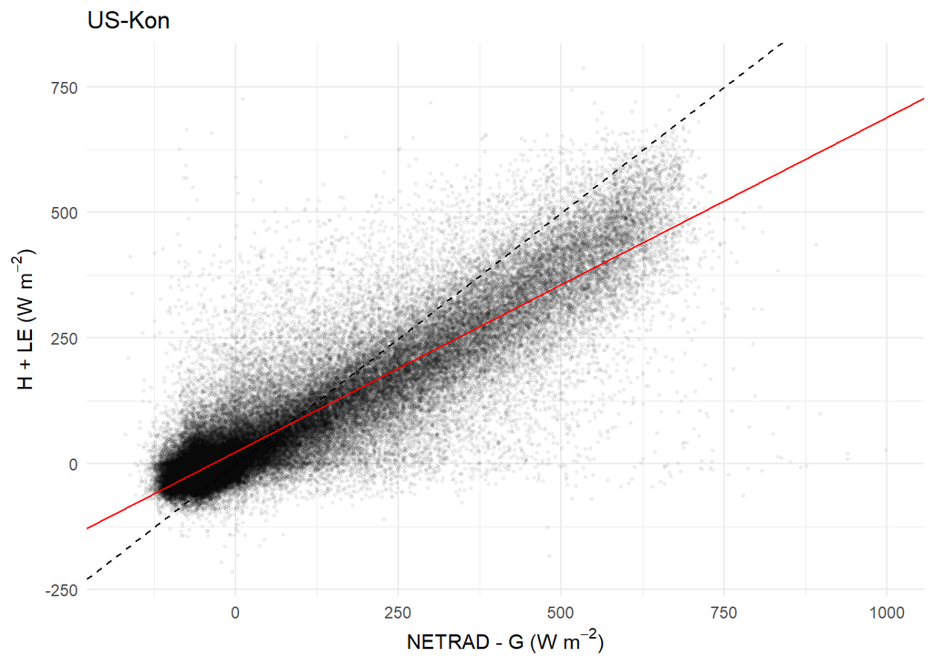

US-Kon: H + LE against NETRAD − G (W m⁻²) for half hours with measured H and LE. Dashed line = 1:1, red line = linear fit.

```r
eb <- all_hh |>
  filter(site == "US-Kon", H_F_MDS_QC == 0, LE_F_MDS_QC == 0) |>
  transmute(avail = NETRAD - G_F_MDS, turb = H_F_MDS + LE_F_MDS) |>
  filter(!is.na(avail), !is.na(turb))

fit <- lm(turb ~ avail, data = eb)
slope <- coef(fit)[["avail"]]

ggplot(eb, aes(avail, turb)) +
  geom_point(alpha = 0.05, size = 0.5) +
  geom_abline(slope = 1, intercept = 0, linetype = "dashed") +
  geom_abline(slope = slope, intercept = coef(fit)[["(Intercept)"]], colour = "red") +
  labs(title = "US-Kon",
       x = expression("NETRAD - G (W " * m^-2 * ")"),
       y = expression("H + LE (W " * m^-2 * ")")) +
  theme_minimal()
```

Number of half hours used: 116230. Slope of the linear fit: 0.67 (R² = 0.8).

```r
conv <- 1.0378

annual <- all_hh |>
  mutate(year = as.integer(format(time, "%Y"))) |>
  group_by(site, year) |>
  filter(n() >= 17520, sum(!is.na(NEE_VUT_REF)) > 0.5 * n()) |>
  summarise(NEE_gC = mean(NEE_VUT_REF, na.rm = TRUE) * conv * 365, .groups = "drop")

comparison <- annual |>
  group_by(site) |>
  summarise(`Mean annual NEE (g C m-2 yr-1)` = mean(NEE_gC), n_years = n())

seasonal <- daily |>
  mutate(month = as.integer(format(date, "%m"))) |>
  group_by(site, month) |>
  summarise(GPP = mean(GPP, na.rm = TRUE), .groups = "drop") |>
  group_by(site) |>
  summarise(`GPP seasonal amplitude (g C m-2 d-1)` = max(GPP) - min(GPP))

gapfilled <- all_hh |>
  group_by(site) |>
  summarise(`Share not measured NEE (%)` = 100 * mean(NEE_VUT_REF_QC != 0, na.rm = TRUE))

kable(comparison |> left_join(seasonal, by = "site") |> left_join(gapfilled, by = "site"),
      digits = 1)
```

| site | Mean annual NEE (g C m-2 yr-1) | n_years | GPP seasonal amplitude (g C m-2 d-1) | Share not measured NEE (%) |
| --- | --- | --- | --- | --- |
| AU-Cpr | -195.0 | 15 | 0.8 | 49.9 |
| CN-Lch | -667.9 | 12 | 15.8 | 66.2 |
| DE-Lnf | -608.1 | 20 | 12.6 | 64.1 |
| FI-Let | -16.1 | 16 | 10.4 | 72.0 |
| US-Kon | -115.8 | 16 | 13.4 | 56.9 |

Among the five towers, the cropland CN-Lch takes up the most carbon, with a mean annual NEE of about −668 g C m⁻² yr⁻¹, followed by the broadleaf forest DE-Lnf (−608 g C m⁻² yr⁻¹, based on *CUT* values). US-Kon (−116) and AU-Cpr (−195) are moderate sinks, and the needleleaf forest FI-Let is almost carbon neutral (−16 g C m⁻² yr⁻¹). The seasonal cycle, measured as the difference between the highest and lowest monthly mean GPP, is largest at CN-Lch (15.8 g C m⁻² d⁻¹), followed by US-Kon (13.4) and DE-Lnf (12.6), and by far the smallest at the savanna AU-Cpr (0.8). Between 50 % (AU-Cpr) and 72 % (FI-Let) of the half-hourly NEE values are not directly measured, meaning they are gap-filled or of lower quality (NEE_VUT_REF_QC != 0), so the annual sums depend strongly on the gap-filling. DE-Lnf has no *VUT* values in its file, so _CUT_REF was used, and it has no data in 2007–2009 and partial gaps in 2022–2023. Annual sums include only years with more than half of the NEE values present, which is why DE-Lnf has 20 years instead of 23.

For DE-Lnf, the VUT (variable USTAR threshold) products are not available in the delivered file. The CUT (constant USTAR threshold) products were used instead. They differ only in how the turbulence threshold for night-time data is determined.

# Data and citation

**Snapshot and files:** fluxnet_shuttle_snapshot_20261119T101149.csv; AMF_US-Kon_FLUXNET_2004-2019_v1.3_r1.zip; ICOS_FI-Let_FLUXNET_2010-2025_v1.3_r1.zip; EUF_DE-Lnf_FLUXNET_2002-2024_v1.3_r1.zip; CNF_CN-Lch_FLUXNET_2008-2020_v1.3_r1.zip; TERN_AU-Cpr_FLUXNET_2010-2025_v1.3_r1.zip.

**Variables used:** `_VUT_REF` for NEE (`NEE_VUT_REF`), night-time partitioning for GPP and RECO (`GPP_NT_VUT_REF`, `RECO_NT_VUT_REF`), gap-filled meteorology (`_F`) and `H_F_MDS`, `LE_F_MDS`. Exception: for DE-Lnf the `_CUT_REF` variants were used because the `_VUT_` columns are empty. Time stamps are local standard time.

**Data citations:**

```r
cat(paste0("- ", snap$site_id, ": ", snap$product_citation), sep = "\n")
```

- US-Kon: Nathaniel Brunsell (2026), AmeriFlux FLUXNET-1F US-Kon Konza Prairie LTER (KNZ), Ver. v1.3_r1 (2004-2019), AmeriFlux AMP, (Dataset). https://doi.org/10.17190/AMF/2316062
- FI-Let: Korkiakoski, M., Aaltonen, H., Aurela, M., Hatakka, J., Laurila, T., Lohila, A., Rainne, J., Tuovinen, J.-P. (2026). Fluxnet Archive Product from Lettosuo, 2010–2025, FLUXNET, https://hdl.handle.net/11676/lJA2M5NajEvo4LNStPxtuMhX
- DE-Lnf: Klosterhalfen, A., Knohl, A., Markwitz, C., Tiedemann, F. (2026). Fluxnet Archive Product from Leinefelde, 2002–2024, FLUXNET, https://hdl.handle.net/11676/Iy6uj-QptZzaR9BFnqiv4hF6
- CN-Lch: Zhang, Y. (2026). Fluxnet Archive Product from Luancheng, 2008–2020, FLUXNET, https://hdl.handle.net/11676/z2J76ckVo1ywgV-s6QoYLklQ
- AU-Cpr: Meyer, W., Ewenz, C., Koerber, G., Lubcke, T. (2026): Calperum Chowilla FLUXNET Release 2026_r1. Version 2026_r1. Terrestrial Ecosystem Research Network (TERN). (Dataset).

**Method reference:** Pastorello, G. et al. (2020). The FLUXNET2015 dataset and the ONEFlux processing pipeline for eddy covariance data. *Scientific Data* 7, 225. https://doi.org/10.1038/s41597-020-0534-3

**Acknowledgement:** FLUXNET data products were produced and harmonized by eddy covariance regional networks and data processing centers, including AmeriFlux, ChinaFlux, European Fluxes Database, ICOS, JapanFlux, KoFlux, OzFlux, SAEON, and TERN. These products also include a modified version of ERA5 hourly data provided by the Copernicus Climate Change Service.